# Udacity Nanodegree Data Analysis

- Project Intro to Data Analysis
- Student: Guillermo Naranjo
- Date: August 2nd, 2017

## Dataset and organization

This jupyter notebook will contain both project report and code. I will use The **Lahman Baseball Database**, working with four CSVs:

- MASTER - Player names, DOB, and biographical info
- Salaries - player salary data
- Teams - yearly stats and standings
- Batting batting statistics

## Initial questions that I would like to ask witht the analysis

As an team manager I want to know how money traslates to wins to drive investment in key positions.

```python
import pandas as pd
import numpy as np

pd.set_option('float_format', '{:2f}'.format)
```

## Data acquisition

### Players Master dataframe

```python
#Exploring first dataset MASTER to know more about structure and data formats

master_df = pd.read_csv('./Master.csv')
master_df.head()
```

|  | playerID | birthYear | birthMonth | birthDay | birthCountry | birthState | birthCity | deathYear | deathMonth | deathDay | ... | nameLast | nameGiven | weight | height | bats | throws | debut | finalGame | retroID | bbrefID |
| --- | --- | --- | --- | --- | --- | --- | --- | --- | --- | --- | --- | --- | --- | --- | --- | --- | --- | --- | --- | --- | --- |
| 0 | aardsda01 | 1981.000000 | 12.000000 | 27.000000 | USA | CO | Denver | nan | nan | nan | ... | Aardsma | David Allan | 215.000000 | 75.000000 | R | R | 2004-04-06 | 2015-08-23 | aardd001 | aardsda01 |
| 1 | aaronha01 | 1934.000000 | 2.000000 | 5.000000 | USA | AL | Mobile | nan | nan | nan | ... | Aaron | Henry Louis | 180.000000 | 72.000000 | R | R | 1954-04-13 | 1976-10-03 | aaroh101 | aaronha01 |
| 2 | aaronto01 | 1939.000000 | 8.000000 | 5.000000 | USA | AL | Mobile | 1984.000000 | 8.000000 | 16.000000 | ... | Aaron | Tommie Lee | 190.000000 | 75.000000 | R | R | 1962-04-10 | 1971-09-26 | aarot101 | aaronto01 |
| 3 | aasedo01 | 1954.000000 | 9.000000 | 8.000000 | USA | CA | Orange | nan | nan | nan | ... | Aase | Donald William | 190.000000 | 75.000000 | R | R | 1977-07-26 | 1990-10-03 | aased001 | aasedo01 |
| 4 | abadan01 | 1972.000000 | 8.000000 | 25.000000 | USA | FL | Palm Beach | nan | nan | nan | ... | Abad | Fausto Andres | 184.000000 | 73.000000 | L | L | 2001-09-10 | 2006-04-13 | abada001 | abadan01 |

5 rows × 24 columns

- There are features like **playerID**, **nameLast** and **nameGiven** that are goig to be important for description purposes. All other fields seems to be out of scope, right now.

### Fielding dataframe

```python
#Exploring second dataset FIELDING to know more about structure and data formats

fielding_df = pd.read_csv('./Fielding.csv')
fielding_df.head()
```

|  | playerID | yearID | stint | teamID | lgID | POS | G | GS | InnOuts | PO | A | E | DP | PB | WP | SB | CS | ZR |
| --- | --- | --- | --- | --- | --- | --- | --- | --- | --- | --- | --- | --- | --- | --- | --- | --- | --- | --- |
| 0 | abercda01 | 1871 | 1 | TRO | NaN | SS | 1 | nan | nan | 1 | 3.000000 | 2.000000 | 0.000000 | nan | nan | nan | nan | nan |
| 1 | addybo01 | 1871 | 1 | RC1 | NaN | 2B | 22 | nan | nan | 67 | 72.000000 | 42.000000 | 5.000000 | nan | nan | nan | nan | nan |
| 2 | addybo01 | 1871 | 1 | RC1 | NaN | SS | 3 | nan | nan | 8 | 14.000000 | 7.000000 | 0.000000 | nan | nan | nan | nan | nan |
| 3 | allisar01 | 1871 | 1 | CL1 | NaN | 2B | 2 | nan | nan | 1 | 4.000000 | 0.000000 | 0.000000 | nan | nan | nan | nan | nan |
| 4 | allisar01 | 1871 | 1 | CL1 | NaN | OF | 29 | nan | nan | 51 | 3.000000 | 7.000000 | 1.000000 | nan | nan | nan | nan | nan |

- Features like **playerID**, **yearID**, **teamID** and **POS** are goig to be important to respond key questions or merging that with other dataframes.

### Salaries

```python
#Exploring third dataset SALARIES to know more about structure and data formats

salaries_df = pd.read_csv('./Salaries.csv')
salaries_df.head(50)
```

|  | yearID | teamID | lgID | playerID | salary |
| --- | --- | --- | --- | --- | --- |
| 0 | 1985 | ATL | NL | barkele01 | 870000 |
| 1 | 1985 | ATL | NL | bedrost01 | 550000 |
| 2 | 1985 | ATL | NL | benedbr01 | 545000 |
| 3 | 1985 | ATL | NL | campri01 | 633333 |
| 4 | 1985 | ATL | NL | ceronri01 | 625000 |
| 5 | 1985 | ATL | NL | chambch01 | 800000 |
| 6 | 1985 | ATL | NL | dedmoje01 | 150000 |
| 7 | 1985 | ATL | NL | forstte01 | 483333 |
| 8 | 1985 | ATL | NL | garbege01 | 772000 |
| 9 | 1985 | ATL | NL | harpete01 | 250000 |
| 10 | 1985 | ATL | NL | hornebo01 | 1500000 |
| 11 | 1985 | ATL | NL | hubbagl01 | 455000 |
| 12 | 1985 | ATL | NL | mahleri01 | 407500 |
| 13 | 1985 | ATL | NL | mcmurcr01 | 275000 |
| 14 | 1985 | ATL | NL | mumphje01 | 775000 |
| 15 | 1985 | ATL | NL | murphda05 | 1625000 |
| 16 | 1985 | ATL | NL | oberkke01 | 616667 |
| 17 | 1985 | ATL | NL | perezpa01 | 450000 |
| 18 | 1985 | ATL | NL | perryge01 | 120000 |
| 19 | 1985 | ATL | NL | ramirra01 | 750000 |
| 20 | 1985 | ATL | NL | suttebr01 | 1354167 |
| 21 | 1985 | ATL | NL | washicl01 | 800000 |
| 22 | 1985 | BAL | AL | boddimi01 | 625000 |
| 23 | 1985 | BAL | AL | dauerri01 | 480000 |
| 24 | 1985 | BAL | AL | davisst02 | 437500 |
| 25 | 1985 | BAL | AL | dempsri01 | 512500 |
| 26 | 1985 | BAL | AL | dwyerji01 | 375000 |
| 27 | 1985 | BAL | AL | flanami01 | 641667 |
| 28 | 1985 | BAL | AL | fordda01 | 450000 |
| 29 | 1985 | BAL | AL | grosswa01 | 483333 |
| 30 | 1985 | BAL | AL | lacyle01 | 725000 |
| 31 | 1985 | BAL | AL | lynnfr01 | 1090000 |
| 32 | 1985 | BAL | AL | martide01 | 560000 |
| 33 | 1985 | BAL | AL | martiti01 | 440000 |
| 34 | 1985 | BAL | AL | mcgresc01 | 547143 |
| 35 | 1985 | BAL | AL | murraed02 | 1472819 |
| 36 | 1985 | BAL | AL | nolanjo01 | 341667 |
| 37 | 1985 | BAL | AL | rayfofl01 | 128500 |
| 38 | 1985 | BAL | AL | ripkeca01 | 800000 |
| 39 | 1985 | BAL | AL | roeniga01 | 558333 |
| 40 | 1985 | BAL | AL | sheetla01 | 60000 |
| 41 | 1985 | BAL | AL | shelbjo01 | 130000 |
| 42 | 1985 | BAL | AL | stewasa01 | 581250 |
| 43 | 1985 | BAL | AL | youngmi01 | 121000 |
| 44 | 1985 | BOS | AL | armasto01 | 915000 |
| 45 | 1985 | BOS | AL | barrema02 | 272500 |
| 46 | 1985 | BOS | AL | boggswa01 | 1000000 |
| 47 | 1985 | BOS | AL | bordiri01 | 115000 |
| 48 | 1985 | BOS | AL | boydoi01 | 177500 |
| 49 | 1985 | BOS | AL | bucknbi01 | 747500 |

- Features like **yearID**, **teamID**, **playerID** and **salary** are goig to be important to respond key questions or merging that with other dataframes.

### Teams

```python
#Exploring fourth dataset TEAMS to know more about structure and data formats

teams_df = pd.read_csv('./Teams.csv')
teams_df.head()
```

|  | yearID | lgID | teamID | franchID | divID | Rank | G | Ghome | W | L | ... | DP | FP | name | park | attendance | BPF | PPF | teamIDBR | teamIDlahman45 | teamIDretro |
| --- | --- | --- | --- | --- | --- | --- | --- | --- | --- | --- | --- | --- | --- | --- | --- | --- | --- | --- | --- | --- | --- |
| 0 | 1871 | NaN | BS1 | BNA | NaN | 3 | 31 | nan | 20 | 10 | ... | nan | 0.838000 | Boston Red Stockings | South End Grounds I | nan | 103 | 98 | BOS | BS1 | BS1 |
| 1 | 1871 | NaN | CH1 | CNA | NaN | 2 | 28 | nan | 19 | 9 | ... | nan | 0.829000 | Chicago White Stockings | Union Base-Ball Grounds | nan | 104 | 102 | CHI | CH1 | CH1 |
| 2 | 1871 | NaN | CL1 | CFC | NaN | 8 | 29 | nan | 10 | 19 | ... | nan | 0.814000 | Cleveland Forest Citys | National Association Grounds | nan | 96 | 100 | CLE | CL1 | CL1 |
| 3 | 1871 | NaN | FW1 | KEK | NaN | 7 | 19 | nan | 7 | 12 | ... | nan | 0.803000 | Fort Wayne Kekiongas | Hamilton Field | nan | 101 | 107 | KEK | FW1 | FW1 |
| 4 | 1871 | NaN | NY2 | NNA | NaN | 5 | 33 | nan | 16 | 17 | ... | nan | 0.839000 | New York Mutuals | Union Grounds (Brooklyn) | nan | 90 | 88 | NYU | NY2 | NY2 |

5 rows × 48 columns

- Features like **yearID**, **teamID**, **W** and **name** are goig to be important to respond key questions or merging that with other dataframes.

## Data cleaning

- At first glance it looks like the datasets variables that we are using but I want to verify if there is data missing, bad formated before start merging the dataframes to answer initial questions

```python
#Comparing each dataset shape after droping NaN of key variables

print 'MasterDF shape: %s rows, %s cols' % master_df.shape
master_clean = master_df[['playerID','nameLast','nameGiven']].dropna()
print 'MasterDF shape: %s observations, %s features, after removing NaN cells\n' % master_clean.shape

print 'FieldingDF shape: %s rows, %s cols' % fielding_df.shape
fielding_clean = fielding_df[['playerID','yearID','teamID','POS']].dropna()
print 'FieldingDF shape: %s observations, %s features, after removing NaN cells\n' % fielding_clean.shape

print 'SalariesDF shape: %s rows, %s cols' % salaries_df.shape
salaries_clean = salaries_df[['yearID','teamID','playerID','salary']].dropna()
print 'SalariesDF shape: %s observations, %s features, after removing NaN cells\n' % salaries_clean.shape

print 'TeamsDF shape: %s rows, %s cols' % teams_df.shape
teams_clean = teams_df[['yearID','teamID','W','name']].dropna()
print 'TeamsDF shape: %s observations, %s features, after removing NaN cells' % teams_clean.shape
```

```
MasterDF shape: 19105 rows, 24 cols
MasterDF shape: 19068 observations, 3 features, after removing NaN cells

FieldingDF shape: 136815 rows, 18 cols
FieldingDF shape: 136815 observations, 4 features, after removing NaN cells

SalariesDF shape: 26428 rows, 5 cols
SalariesDF shape: 26428 observations, 4 features, after removing NaN cells

TeamsDF shape: 2835 rows, 48 cols
TeamsDF shape: 2835 observations, 4 features, after removing NaN cells
```

**Describing tables**

```python
master_clean.describe()
```

|  | playerID | nameLast | nameGiven |
| --- | --- | --- | --- |
| count | 19068 | 19068 | 19068 |
| unique | 19068 | 9824 | 12616 |
| top | glenned02 | Smith | John Joseph |
| freq | 1 | 154 | 74 |

```python
fielding_clean.describe()
```

|  | yearID |
| --- | --- |
| count | 136815.000000 |
| mean | 1961.653349 |
| std | 40.949885 |
| min | 1871.000000 |
| 25% | 1928.000000 |
| 50% | 1972.000000 |
| 75% | 1997.000000 |
| max | 2016.000000 |

```python
salaries_clean.describe()
```

|  | yearID | salary |
| --- | --- | --- |
| count | 26428.000000 | 26428.000000 |
| mean | 2000.878727 | 2085634.053125 |
| std | 8.909314 | 3455348.161223 |
| min | 1985.000000 | 0.000000 |
| 25% | 1994.000000 | 294702.000000 |
| 50% | 2001.000000 | 550000.000000 |
| 75% | 2009.000000 | 2350000.000000 |
| max | 2016.000000 | 33000000.000000 |

```python
teams_clean.describe()
```

|  | yearID | W |
| --- | --- | --- |
| count | 2835.000000 | 2835.000000 |
| mean | 1955.681834 | 74.814109 |
| std | 41.767356 | 17.591208 |
| min | 1871.000000 | 0.000000 |
| 25% | 1920.000000 | 66.000000 |
| 50% | 1964.000000 | 77.000000 |
| 75% | 1993.000000 | 87.000000 |
| max | 2016.000000 | 116.000000 |

**Conclusions**

- It seems there are some missing data in master dataframe.
- Fielding dataframe looks complete, without missing values.
- Fielding dataframe even contains data from **1871** to **2016**
- Salaries dataframe looks complete, without missing values, ranging date from **1985** to **2016**. So I have to filter fielding data from 1985 to 2016.
- Interesting enough there are players with **salary 0** (min). It would be great to see the distribution graph.
- Teams dataframe looks complete, without missing values, ranging date from **1871** to **2016**. Number of wins in some cases is 0 or 116 as max. A filter need to be applied to count only data from 1985.

**Filtering by dates**

```python
fielding_clean = fielding_clean[fielding_clean['yearID'] >= 1985]
fielding_clean.describe()
```

|  | yearID |
| --- | --- |
| count | 52558.000000 |
| mean | 2001.478291 |
| std | 9.123193 |
| min | 1985.000000 |
| 25% | 1994.000000 |
| 50% | 2002.000000 |
| 75% | 2009.000000 |
| max | 2016.000000 |

```python
teams_clean = teams_clean[teams_clean['yearID'] >= 1985]
teams_clean.describe()
```

|  | yearID | W |
| --- | --- | --- |
| count | 918.000000 | 918.000000 |
| mean | 2000.978214 | 79.943355 |
| std | 9.135570 | 11.840224 |
| min | 1985.000000 | 43.000000 |
| 25% | 1993.000000 | 71.250000 |
| 50% | 2001.000000 | 80.000000 |
| 75% | 2009.000000 | 89.000000 |
| max | 2016.000000 | 116.000000 |

## Exploration phase

- The first thing I would like to do is create single dataframe that contains the wins and salaries by team and year, grouped by team and year.

```python
#calculating aggregation of salaries by team by year
salaries_wo_players = salaries_clean.drop('playerID',1)
salaries_grp = salaries_wo_players.groupby(['yearID','teamID']).sum().reset_index()
teams_stats = salaries_grp.merge(teams_clean, on=['teamID','yearID'], how='inner')
teams_stats.head()
```

|  | yearID | teamID | salary | W | name |
| --- | --- | --- | --- | --- | --- |
| 0 | 1985 | ATL | 14807000 | 66 | Atlanta Braves |
| 1 | 1985 | BAL | 11560712 | 83 | Baltimore Orioles |
| 2 | 1985 | BOS | 10897560 | 81 | Boston Red Sox |
| 3 | 1985 | CAL | 14427894 | 90 | California Angels |
| 4 | 1985 | CHA | 9846178 | 85 | Chicago White Sox |

```python
teams_stats_recent = teams_stats[teams_stats['yearID'] >= 2011]
teams_stats_recent.head(10)
```

|  | yearID | teamID | salary | W | name |
| --- | --- | --- | --- | --- | --- |
| 738 | 2011 | ARI | 53639833 | 94 | Arizona Diamondbacks |
| 739 | 2011 | ATL | 87002692 | 89 | Atlanta Braves |
| 740 | 2011 | BAL | 85304038 | 69 | Baltimore Orioles |
| 741 | 2011 | BOS | 161762475 | 90 | Boston Red Sox |
| 742 | 2011 | CHA | 127789000 | 79 | Chicago White Sox |
| 743 | 2011 | CHN | 125047329 | 71 | Chicago Cubs |
| 744 | 2011 | CIN | 75947134 | 79 | Cincinnati Reds |
| 745 | 2011 | CLE | 48776566 | 80 | Cleveland Indians |
| 746 | 2011 | COL | 88148071 | 73 | Colorado Rockies |
| 747 | 2011 | DET | 105700231 | 95 | Detroit Tigers |

```python
teams_stats_recent.describe()
```

|  | yearID | salary | W |
| --- | --- | --- | --- |
| count | 169.000000 | 169.000000 | 169.000000 |
| mean | 2013.337278 | 104237626.662722 | 80.757396 |
| std | 1.639859 | 42346698.273719 | 10.955281 |
| min | 2011.000000 | 17890700.000000 | 51.000000 |
| 25% | 2012.000000 | 75337500.000000 | 73.000000 |
| 50% | 2013.000000 | 95403500.000000 | 81.000000 |
| 75% | 2015.000000 | 120693000.000000 | 90.000000 |
| max | 2016.000000 | 231978886.000000 | 102.000000 |

```python
def CalculateWinsByMillon(wins,salary):
    return float(wins / float(salary / 1000000.0))
```

```python
#Adding a new colum: wins by salary ratio in millions
teams_stats_recent.loc[:,('WinByMM')] = teams_stats_recent.apply(lambda row: CalculateWinsByMillon(row['W'], row['salary']), axis=1)
teams_stats_recent = teams_stats_recent.sort_values(by='WinByMM', ascending=False)
teams_stats_recent.head(10)
```

|  | yearID | teamID | salary | W | name | WinByMM |
| --- | --- | --- | --- | --- | --- | --- |
| 808 | 2013 | HOU | 17890700 | 51 | Houston Astros | 2.850643 |
| 764 | 2011 | TBA | 41053571 | 91 | Tampa Bay Rays | 2.216616 |
| 838 | 2014 | HOU | 35116300 | 70 | Houston Astros | 1.993376 |
| 750 | 2011 | KCA | 35712000 | 71 | Kansas City Royals | 1.988127 |
| 812 | 2013 | MIA | 33601900 | 62 | Miami Marlins | 1.845134 |
| 842 | 2014 | MIA | 41836900 | 77 | Miami Marlins | 1.840481 |
| 738 | 2011 | ARI | 53639833 | 94 | Arizona Diamondbacks | 1.752429 |
| 824 | 2013 | TBA | 52955272 | 92 | Tampa Bay Rays | 1.737315 |
| 787 | 2012 | OAK | 55372500 | 94 | Oakland Athletics | 1.697594 |
| 745 | 2011 | CLE | 48776566 | 80 | Cleveland Indians | 1.640132 |

```python
teams_stats_recent['WinByMM'].describe()
```

```
count   169.000000
mean      0.900615
std       0.384749
min       0.366413
25%       0.628147
50%       0.823064
75%       1.073769
max       2.850643
Name: WinByMM, dtype: float64
```

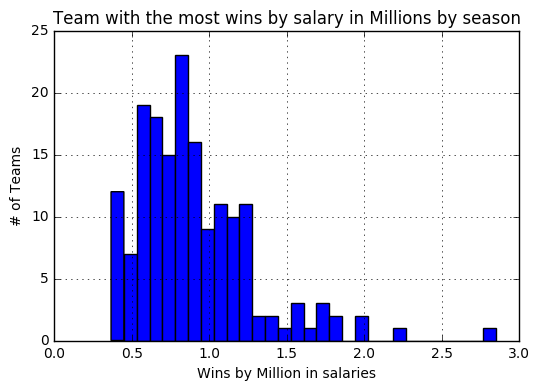

```python
%matplotlib inline
import matplotlib.pyplot as plt
fig, ax = plt.subplots()
plt.hist(teams_stats_recent['WinByMM'], bins=30, normed=False)
plt.xlabel('Wins by Million in salaries')
plt.ylabel('# of Teams')
plt.title('Team with the most wins by salary in Millions by season')
plt.grid(True)
plt.show()
```

**Interesting enough there are 7 teams that reached a ration greater than normal parameters.** A good second question would be what are doing these teams to have that much wins by salary.

```python
teams_stats_recent[isOutlier(teams_stats_recent,'WinByMM')]
```

|  | yearID | teamID | salary | W | name | WinByMM |
| --- | --- | --- | --- | --- | --- | --- |
| 808 | 2013 | HOU | 17890700 | 51 | Houston Astros | 2.850643 |
| 764 | 2011 | TBA | 41053571 | 91 | Tampa Bay Rays | 2.216616 |
| 838 | 2014 | HOU | 35116300 | 70 | Houston Astros | 1.993376 |
| 750 | 2011 | KCA | 35712000 | 71 | Kansas City Royals | 1.988127 |
| 812 | 2013 | MIA | 33601900 | 62 | Miami Marlins | 1.845134 |
| 842 | 2014 | MIA | 41836900 | 77 | Miami Marlins | 1.840481 |
| 738 | 2011 | ARI | 53639833 | 94 | Arizona Diamondbacks | 1.752429 |

Now, lets remove outlier and see a graph without removing outliers.

```python
#Removing outliers, defining a function
def remove_outliers(dataset, field):
    Q1 = dataset[field].quantile(0.25)
    Q3 = dataset[field].quantile(0.75)
    IQR = Q3 - Q1
    not_outliers = (dataset[field] > Q1 - 1.5 * IQR) & (dataset[field] < Q3 + 1.5 * IQR)
    return dataset[not_outliers]
```

```python
def isOutlier(dataset, field):
    Q1 = dataset[field].quantile(0.25)
    Q3 = dataset[field].quantile(0.75)
    IQR = Q3 - Q1
    outliers = (dataset[field] < Q1 - 1.5 * IQR) | (dataset[field] > Q3 + 1.5 * IQR)
    return outliers
```

```python
teams_stats_no_outliers = remove_outliers(teams_stats_recent,'WinByMM')
```

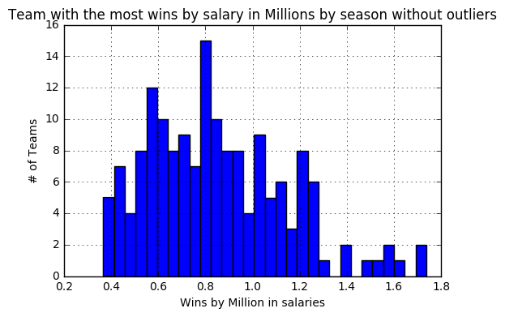

```python
fig, ax = plt.subplots()
plt.hist(teams_stats_no_outliers['WinByMM'], bins=30, normed=False)
plt.xlabel('Wins by Million in salaries')
plt.ylabel('# of Teams')
plt.title('Team with the most wins by salary in Millions by season without outliers')
plt.grid(True)
plt.show()
```

### Now lets see the correlation between wins and salary

- I'm not wrting the correlation function as described in the lessons, to standarize the variables. Instead I'll use NumPy function. Later I use pandas corr function as well

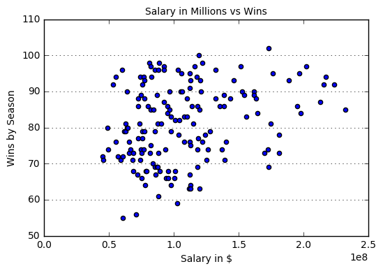

```python
fig, axis = plt.subplots()
# Grid lines, Xticks, Xlabel, Ylabel

axis.yaxis.grid(True)
axis.set_title('Salary in Millions vs Wins',fontsize=10)
axis.set_xlabel('Salary in $',fontsize=10)
axis.set_ylabel('Wins by Season',fontsize=10)

X = teams_stats_no_outliers['salary']
Y = teams_stats_no_outliers['W']

axis.scatter(X, Y)
plt.show()
```

```python
np.corrcoef(teams_stats_no_outliers['salary'],teams_stats_no_outliers['W'],ddof=0)
```

```
array([[ 1.        ,  0.28618816],
       [ 0.28618816,  1.        ]])
```

**Conclusions for initial exploration**

## Additional analysis, looking for features that traslates to wins in winning teams

- In this case I will still focus in the 7 teams that has a curious high wins rate per Million invested:

```python
teams_stats_recent = teams_stats_recent[isOutlier(teams_stats_recent,'WinByMM')]
teams_stats_recent.head(10)
```

|  | yearID | teamID | salary | W | name | WinByMM |
| --- | --- | --- | --- | --- | --- | --- |
| 808 | 2013 | HOU | 17890700 | 51 | Houston Astros | 2.850643 |
| 764 | 2011 | TBA | 41053571 | 91 | Tampa Bay Rays | 2.216616 |
| 838 | 2014 | HOU | 35116300 | 70 | Houston Astros | 1.993376 |
| 750 | 2011 | KCA | 35712000 | 71 | Kansas City Royals | 1.988127 |
| 812 | 2013 | MIA | 33601900 | 62 | Miami Marlins | 1.845134 |
| 842 | 2014 | MIA | 41836900 | 77 | Miami Marlins | 1.840481 |
| 738 | 2011 | ARI | 53639833 | 94 | Arizona Diamondbacks | 1.752429 |

```python
team_start_full = teams_df[['teamID','yearID','name','Rank','W','L','R','AB','H','2B','3B','HR','BB','SO','SB','CS','HBP','SF','RA','ER','ERA','CG','SHO','SV','IPouts','HA','HRA','BBA','SOA','E','DP','FP','attendance']]
team_start_full = teams_stats_recent.merge(team_start_full, on=['teamID','yearID','W','name'], how='inner')
```

```python
team_start_full.head(10)
```

|  | yearID | teamID | salary | W | name | WinByMM | Rank | L | R | AB | ... | SV | IPouts | HA | HRA | BBA | SOA | E | DP | FP | attendance |
| --- | --- | --- | --- | --- | --- | --- | --- | --- | --- | --- | --- | --- | --- | --- | --- | --- | --- | --- | --- | --- | --- |
| 0 | 2013 | HOU | 17890700 | 51 | Houston Astros | 2.850643 | 5 | 111 | 610 | 5457 | ... | 32 | 4320 | 1530 | 191 | 616 | 1084 | 125 | 168.000000 | 0.979000 | 1651883.000000 |
| 1 | 2011 | TBA | 41053571 | 91 | Tampa Bay Rays | 2.216616 | 2 | 71 | 707 | 5436 | ... | 32 | 4347 | 1263 | 161 | 504 | 1143 | 73 | 138.000000 | 0.988000 | 1529188.000000 |
| 2 | 2014 | HOU | 35116300 | 70 | Houston Astros | 1.993376 | 4 | 92 | 629 | 5447 | ... | 31 | 4316 | 1437 | 139 | 484 | 1137 | 106 | 151.000000 | 0.983000 | 1751829.000000 |
| 3 | 2011 | KCA | 35712000 | 71 | Kansas City Royals | 1.988127 | 4 | 91 | 730 | 5672 | ... | 37 | 4354 | 1487 | 163 | 557 | 1080 | 95 | 149.000000 | 0.985000 | 1724450.000000 |
| 4 | 2013 | MIA | 33601900 | 62 | Miami Marlins | 1.845134 | 5 | 100 | 513 | 5449 | ... | 36 | 4380 | 1376 | 121 | 526 | 1177 | 88 | 144.000000 | 0.986000 | 1586322.000000 |
| 5 | 2014 | MIA | 41836900 | 77 | Miami Marlins | 1.840481 | 4 | 85 | 645 | 5538 | ... | 42 | 4373 | 1481 | 114 | 458 | 1190 | 97 | 154.000000 | 0.984000 | 1732283.000000 |
| 6 | 2011 | ARI | 53639833 | 94 | Arizona Diamondbacks | 1.752429 | 1 | 68 | 731 | 5421 | ... | 58 | 4330 | 1414 | 159 | 442 | 1058 | 90 | 131.000000 | 0.985000 | 2105432.000000 |

7 rows × 35 columns

- Now, lets map the correlations betweeen features in Teams agains Wins for our 7 winning and high performing salary teams

```python
corr_df = team_start_full.corr(method='pearson', min_periods=1)
corr_df.head(33)
```

|  | yearID | salary | W | WinByMM | Rank | L | R | AB | H | 2B | ... | SV | IPouts | HA | HRA | BBA | SOA | E | DP | FP | attendance |
| --- | --- | --- | --- | --- | --- | --- | --- | --- | --- | --- | --- | --- | --- | --- | --- | --- | --- | --- | --- | --- | --- |
| yearID | 1.000000 | -0.397310 | -0.548620 | 0.062738 | 0.653710 | 0.548620 | -0.688612 | -0.158797 | -0.394490 | -0.751456 | ... | -0.349791 | 0.046834 | 0.401311 | -0.508020 | -0.028335 | 0.612143 | 0.531726 | 0.605280 | -0.503040 | -0.211441 |
| salary | -0.397310 | 1.000000 | 0.919485 | -0.809732 | -0.823406 | -0.919485 | 0.535180 | -0.089822 | 0.185069 | 0.244994 | ... | 0.754100 | 0.182041 | -0.438713 | -0.380826 | -0.898529 | -0.025909 | -0.699312 | -0.868937 | 0.671552 | 0.612477 |
| W | -0.548620 | 0.919485 | 1.000000 | -0.559823 | -0.938697 | -1.000000 | 0.693820 | -0.156857 | 0.163522 | 0.350260 | ... | 0.579344 | 0.027612 | -0.601218 | -0.135211 | -0.777817 | -0.093212 | -0.753253 | -0.843662 | 0.701900 | 0.442347 |
| WinByMM | 0.062738 | -0.809732 | -0.559823 | 1.000000 | 0.356045 | 0.559823 | -0.121791 | -0.125188 | -0.200855 | 0.037433 | ... | -0.549166 | -0.481668 | 0.270293 | 0.749922 | 0.810756 | -0.277885 | 0.604406 | 0.698416 | -0.644830 | -0.426124 |
| Rank | 0.653710 | -0.823406 | -0.938697 | 0.356045 | 1.000000 | 0.938697 | -0.740489 | 0.292641 | -0.083546 | -0.438587 | ... | -0.639929 | 0.233362 | 0.521962 | -0.155723 | 0.632944 | 0.375107 | 0.584847 | 0.801419 | -0.515327 | -0.567080 |
| L | 0.548620 | -0.919485 | -1.000000 | 0.559823 | 0.938697 | 1.000000 | -0.693820 | 0.156857 | -0.163522 | -0.350260 | ... | -0.579344 | -0.027612 | 0.601218 | 0.135211 | 0.777817 | 0.093212 | 0.753253 | 0.843662 | -0.701900 | -0.442347 |
| R | -0.688612 | 0.535180 | 0.693820 | -0.121791 | -0.740489 | -0.693820 | 1.000000 | 0.321601 | 0.660811 | 0.873283 | ... | 0.409847 | -0.314247 | -0.077097 | 0.407323 | -0.273549 | -0.584917 | -0.283262 | -0.393785 | 0.250362 | 0.465899 |
| AB | -0.158797 | -0.089822 | -0.156857 | -0.125188 | 0.292641 | 0.156857 | 0.321601 | 1.000000 | 0.916413 | 0.589068 | ... | -0.090929 | 0.338985 | 0.455100 | -0.018890 | 0.250569 | -0.099838 | 0.053802 | 0.244308 | 0.017189 | -0.084964 |
| H | -0.394490 | 0.185069 | 0.163522 | -0.200855 | -0.083546 | -0.163522 | 0.660811 | 0.916413 | 1.000000 | 0.824617 | ... | 0.167023 | 0.123557 | 0.371955 | 0.130214 | 0.046235 | -0.352599 | -0.047965 | 0.009692 | 0.093207 | 0.209812 |
| 2B | -0.751456 | 0.244994 | 0.350260 | 0.037433 | -0.438587 | -0.350260 | 0.873283 | 0.589068 | 0.824617 | 1.000000 | ... | 0.334837 | -0.208280 | 0.191135 | 0.566053 | 0.113272 | -0.738595 | -0.082875 | -0.173130 | 0.074400 | 0.374698 |
| 3B | -0.626331 | 0.707204 | 0.675133 | -0.629250 | -0.510761 | -0.675133 | 0.536373 | 0.448955 | 0.570616 | 0.515338 | ... | 0.484123 | 0.598097 | -0.360462 | -0.264443 | -0.431436 | 0.017507 | -0.778288 | -0.659977 | 0.775132 | 0.176174 |
| HR | -0.365993 | 0.290985 | 0.539924 | 0.216674 | -0.714515 | -0.539924 | 0.654255 | -0.398222 | -0.054366 | 0.354359 | ... | 0.158479 | -0.795595 | -0.256350 | 0.542654 | -0.235999 | -0.520500 | -0.042251 | -0.275517 | -0.020437 | 0.371080 |
| BB | -0.327231 | 0.714909 | 0.900311 | -0.299962 | -0.846634 | -0.900311 | 0.562164 | -0.381505 | -0.094442 | 0.117274 | ... | 0.288294 | -0.136841 | -0.677690 | -0.086975 | -0.701500 | 0.073216 | -0.635962 | -0.645503 | 0.568267 | 0.207799 |
| SO | 0.762568 | -0.416470 | -0.410482 | 0.455839 | 0.320598 | 0.410482 | -0.440229 | -0.514857 | -0.580404 | -0.567803 | ... | -0.182106 | -0.409907 | 0.377794 | 0.010227 | 0.066056 | 0.199168 | 0.684305 | 0.602441 | -0.730497 | -0.006667 |
| SB | -0.780243 | 0.145488 | 0.383855 | 0.169434 | -0.524287 | -0.383855 | 0.705079 | 0.110406 | 0.353929 | 0.684795 | ... | -0.044115 | -0.510850 | -0.316362 | 0.668646 | 0.149155 | -0.672137 | -0.253807 | -0.359163 | 0.256969 | 0.103955 |
| CS | -0.761076 | -0.122615 | 0.153373 | 0.539020 | -0.396595 | -0.153373 | 0.585035 | 0.009927 | 0.217788 | 0.680635 | ... | -0.022181 | -0.553893 | -0.117446 | 0.930906 | 0.445347 | -0.793598 | 0.013282 | -0.091320 | -0.053819 | 0.059519 |
| HBP | -0.406939 | 0.180006 | 0.395729 | 0.139625 | -0.529956 | -0.395729 | 0.056765 | -0.756488 | -0.602555 | -0.165848 | ... | -0.043533 | -0.328418 | -0.794055 | 0.293176 | -0.106583 | -0.125505 | -0.435195 | -0.525233 | 0.381498 | -0.089129 |
| SF | -0.302593 | -0.114407 | -0.061519 | 0.103145 | 0.094323 | 0.061519 | 0.586260 | 0.901078 | 0.940489 | 0.790046 | ... | -0.107717 | -0.064577 | 0.464092 | 0.328317 | 0.309803 | -0.398131 | 0.170514 | 0.267233 | -0.121018 | 0.027664 |
| RA | 0.204616 | -0.746100 | -0.725760 | 0.698253 | 0.539440 | 0.725760 | -0.051786 | 0.318928 | 0.239104 | 0.253518 | ... | -0.297378 | -0.500813 | 0.826233 | 0.608215 | 0.743731 | -0.491625 | 0.907099 | 0.813454 | -0.886486 | -0.006491 |
| ER | 0.104282 | -0.741202 | -0.712066 | 0.683035 | 0.531908 | 0.712066 | -0.006357 | 0.402012 | 0.319434 | 0.333466 | ... | -0.316047 | -0.457207 | 0.791005 | 0.639074 | 0.788631 | -0.527255 | 0.842758 | 0.771792 | -0.814229 | -0.041983 |
| ERA | 0.099840 | -0.732892 | -0.696953 | 0.692180 | 0.506258 | 0.696953 | 0.007345 | 0.369505 | 0.300335 | 0.333304 | ... | -0.309193 | -0.499824 | 0.781730 | 0.659397 | 0.777234 | -0.549114 | 0.849670 | 0.761146 | -0.823399 | -0.021193 |
| CG | -0.337859 | 0.320911 | 0.623063 | 0.032802 | -0.594609 | -0.623063 | 0.370098 | -0.411811 | -0.234423 | 0.004902 | ... | -0.204600 | -0.212452 | -0.820727 | 0.111874 | -0.302473 | 0.121985 | -0.591481 | -0.463062 | 0.546596 | -0.241987 |
| SHO | -0.099690 | 0.554975 | 0.501419 | -0.472992 | -0.330414 | -0.501419 | -0.032840 | -0.150769 | -0.144442 | -0.183138 | ... | 0.437378 | 0.726480 | -0.445860 | -0.542697 | -0.530657 | 0.504840 | -0.642869 | -0.466677 | 0.580858 | -0.003085 |
| SV | -0.349791 | 0.754100 | 0.579344 | -0.549166 | -0.639929 | -0.579344 | 0.409847 | -0.090929 | 0.167023 | 0.334837 | ... | 1.000000 | 0.050719 | 0.058406 | -0.100444 | -0.603869 | -0.372901 | -0.222867 | -0.574179 | 0.171164 | 0.879212 |
| IPouts | 0.046834 | 0.182041 | 0.027612 | -0.481668 | 0.233362 | -0.027612 | -0.314247 | 0.338985 | 0.123557 | -0.208280 | ... | 0.050719 | 1.000000 | -0.205039 | -0.674685 | -0.151587 | 0.645709 | -0.505986 | -0.175214 | 0.530282 | -0.345793 |
| HA | 0.401311 | -0.438713 | -0.601218 | 0.270293 | 0.521962 | 0.601218 | -0.077097 | 0.455100 | 0.371955 | 0.191135 | ... | 0.058406 | -0.205039 | 1.000000 | 0.176340 | 0.367554 | -0.296908 | 0.854993 | 0.718578 | -0.828617 | 0.276545 |
| HRA | -0.508020 | -0.380826 | -0.135211 | 0.749922 | -0.155723 | 0.135211 | 0.407323 | -0.018890 | 0.130214 | 0.566053 | ... | -0.100444 | -0.674685 | 0.176340 | 1.000000 | 0.618171 | -0.811727 | 0.367203 | 0.228065 | -0.410154 | 0.057766 |
| BBA | -0.028335 | -0.898529 | -0.777817 | 0.810756 | 0.632944 | 0.777817 | -0.273549 | 0.250569 | 0.046235 | 0.113272 | ... | -0.603869 | -0.151587 | 0.367554 | 0.618171 | 1.000000 | -0.264174 | 0.535688 | 0.682219 | -0.514404 | -0.532065 |
| SOA | 0.612143 | -0.025909 | -0.093212 | -0.277885 | 0.375107 | 0.093212 | -0.584917 | -0.099838 | -0.352599 | -0.738595 | ... | -0.372901 | 0.645709 | -0.296908 | -0.811727 | -0.264174 | 1.000000 | -0.279906 | 0.085438 | 0.300899 | -0.568486 |
| E | 0.531726 | -0.699312 | -0.753253 | 0.604406 | 0.584847 | 0.753253 | -0.283262 | 0.053802 | -0.047965 | -0.082875 | ... | -0.222867 | -0.505986 | 0.854993 | 0.367203 | 0.535688 | -0.279906 | 1.000000 | 0.846903 | -0.991093 | 0.082024 |
| DP | 0.605280 | -0.868937 | -0.843662 | 0.698416 | 0.801419 | 0.843662 | -0.393785 | 0.244308 | 0.009692 | -0.173130 | ... | -0.574179 | -0.175214 | 0.718578 | 0.228065 | 0.682219 | 0.085438 | 0.846903 | 1.000000 | -0.829898 | -0.397421 |
| FP | -0.503040 | 0.671552 | 0.701900 | -0.644830 | -0.515327 | -0.701900 | 0.250362 | 0.017189 | 0.093207 | 0.074400 | ... | 0.171164 | 0.530282 | -0.828617 | -0.410154 | -0.514404 | 0.300899 | -0.991093 | -0.829898 | 1.000000 | -0.109348 |
| attendance | -0.211441 | 0.612477 | 0.442347 | -0.426124 | -0.567080 | -0.442347 | 0.465899 | -0.084964 | 0.209812 | 0.374698 | ... | 0.879212 | -0.345793 | 0.276545 | 0.057766 | -0.532065 | -0.568486 | 0.082024 | -0.397421 | -0.109348 | 1.000000 |

33 rows × 33 columns

## Positive correlation with wins

```python
corr_df['W'] > 0.80
```

```
yearID        False
salary         True
W              True
WinByMM       False
Rank          False
L             False
R             False
AB            False
H             False
2B            False
3B            False
HR            False
BB             True
SO            False
SB            False
CS            False
HBP           False
SF            False
RA            False
ER            False
ERA           False
CG            False
SHO           False
SV            False
IPouts        False
HA            False
HRA           False
BBA           False
SOA           False
E             False
DP            False
FP            False
attendance    False
Name: W, dtype: bool
```

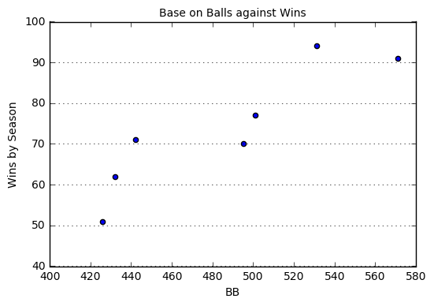

```python
fig, axis = plt.subplots()
axis.yaxis.grid(True)
axis.set_title('Base on Balls against Wins',fontsize=10)
axis.set_xlabel('BB',fontsize=10)
axis.set_ylabel('Wins by Season',fontsize=10)

X = team_start_full['BB']
Y = team_start_full['W']

axis.scatter(X, Y)
plt.show()
```

**It seems there is a positive correlation between Base on Balls and Wins. So maybe its bacause those teams have heavy hitters in the team**

## Negative correlation with wins

```python
corr_df['W'] < -0.80
```

```
yearID        False
salary        False
W             False
WinByMM       False
Rank           True
L              True
R             False
AB            False
H             False
2B            False
3B            False
HR            False
BB            False
SO            False
SB            False
CS            False
HBP           False
SF            False
RA            False
ER            False
ERA           False
CG            False
SHO           False
SV            False
IPouts        False
HA            False
HRA           False
BBA           False
SOA           False
E             False
DP             True
FP            False
attendance    False
Name: W, dtype: bool
```

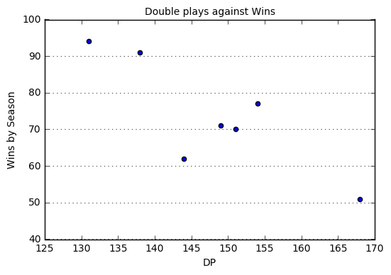

```python
fig, axis = plt.subplots()
# Grid lines, Xticks, Xlabel, Ylabel

axis.yaxis.grid(True)
axis.set_title('Double plays against Wins',fontsize=10)
axis.set_xlabel('DP',fontsize=10)
axis.set_ylabel('Wins by Season',fontsize=10)

X = team_start_full['DP']
Y = team_start_full['W']

axis.scatter(X, Y)
plt.show()
```

**It seems there is a negative correlation between Double Plays and Wins. It's weird that those with the highest wins dont invest that much trying to do Double Plays** .

### Players with most BB by teams and salaries

I would like to compare the Base on Balls distribution for those 7 more Winning Teams and the whole dataframe.

```python
#Exploring BATTING dataset to know more about structure and data formats

batting_df = pd.read_csv('./Batting.csv')
batting_df.head()
```

|  | playerID | yearID | stint | teamID | lgID | G | AB | R | H | 2B | ... | RBI | SB | CS | BB | SO | IBB | HBP | SH | SF | GIDP |
| --- | --- | --- | --- | --- | --- | --- | --- | --- | --- | --- | --- | --- | --- | --- | --- | --- | --- | --- | --- | --- | --- |
| 0 | abercda01 | 1871 | 1 | TRO | NaN | 1 | 4 | 0 | 0 | 0 | ... | 0.000000 | 0.000000 | 0.000000 | 0 | 0.000000 | nan | nan | nan | nan | nan |
| 1 | addybo01 | 1871 | 1 | RC1 | NaN | 25 | 118 | 30 | 32 | 6 | ... | 13.000000 | 8.000000 | 1.000000 | 4 | 0.000000 | nan | nan | nan | nan | nan |
| 2 | allisar01 | 1871 | 1 | CL1 | NaN | 29 | 137 | 28 | 40 | 4 | ... | 19.000000 | 3.000000 | 1.000000 | 2 | 5.000000 | nan | nan | nan | nan | nan |
| 3 | allisdo01 | 1871 | 1 | WS3 | NaN | 27 | 133 | 28 | 44 | 10 | ... | 27.000000 | 1.000000 | 1.000000 | 0 | 2.000000 | nan | nan | nan | nan | nan |
| 4 | ansonca01 | 1871 | 1 | RC1 | NaN | 25 | 120 | 29 | 39 | 11 | ... | 16.000000 | 6.000000 | 2.000000 | 2 | 1.000000 | nan | nan | nan | nan | nan |

5 rows × 22 columns

```python
#filtering those player of winning teams
#team_start_full = teams_df[['teamID','yearID','name','Rank','W','L','R','AB','H','2B','3B','HR','BB','SO','SB','CS','HBP','SF','RA','ER','ERA','CG','SHO','SV','IPouts','HA','HRA','BBA','SOA','E','DP','FP','attendance']]
winningbatters = team_start_full.merge(batting_df, on=['teamID','yearID'], how='inner').reset_index()
print 'WinningBattersWalks: %s observations, %s features, after removing NaN cells' % winningbatters.shape
winningbatters.head()
```

```
WinningBattersWalks: 331 observations, 56 features, after removing NaN cells
```

|  | index | yearID | teamID | salary | W | name | WinByMM | Rank | L | R_x | ... | RBI | SB_y | CS_y | BB_y | SO_y | IBB | HBP_y | SH | SF_y | GIDP |
| --- | --- | --- | --- | --- | --- | --- | --- | --- | --- | --- | --- | --- | --- | --- | --- | --- | --- | --- | --- | --- | --- |
| 0 | 0 | 2013 | HOU | 17890700 | 51 | Houston Astros | 2.850643 | 5 | 111 | 610 | ... | 52.000000 | 35.000000 | 13.000000 | 32 | 85.000000 | 5.000000 | 2.000000 | 4.000000 | 8.000000 | 24.000000 |
| 1 | 1 | 2013 | HOU | 17890700 | 51 | Houston Astros | 2.850643 | 5 | 111 | 610 | ... | 0.000000 | 0.000000 | 0.000000 | 0 | 0.000000 | 0.000000 | 0.000000 | 0.000000 | 0.000000 | 0.000000 |
| 2 | 2 | 2013 | HOU | 17890700 | 51 | Houston Astros | 2.850643 | 5 | 111 | 610 | ... | 11.000000 | 0.000000 | 0.000000 | 3 | 35.000000 | 0.000000 | 0.000000 | 0.000000 | 0.000000 | 0.000000 |
| 3 | 3 | 2013 | HOU | 17890700 | 51 | Houston Astros | 2.850643 | 5 | 111 | 610 | ... | 41.000000 | 11.000000 | 11.000000 | 21 | 127.000000 | 0.000000 | 8.000000 | 6.000000 | 2.000000 | 5.000000 |
| 4 | 4 | 2013 | HOU | 17890700 | 51 | Houston Astros | 2.850643 | 5 | 111 | 610 | ... | 0.000000 | 0.000000 | 0.000000 | 0 | 1.000000 | 0.000000 | 0.000000 | 1.000000 | 0.000000 | 0.000000 |

5 rows × 56 columns

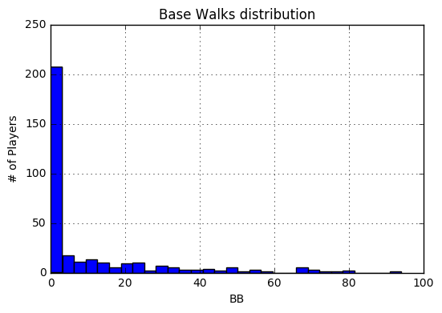

```python
fig, ax = plt.subplots()
plt.hist(winningbatters['BB_y'], bins=30, normed=False)
plt.xlabel('BB')
plt.ylabel('# of Players')
plt.title('Base Walks distribution')
plt.grid(True)
plt.show()
```

```python
winningbatters['BB_y'].describe()
```

```
count   331.000000
mean     10.265861
std      18.253319
min       0.000000
25%       0.000000
50%       1.000000
75%      12.500000
max      94.000000
Name: BB_y, dtype: float64
```

- There are 331 players in those 7 winning teams, there is are very differents BB rates by player.

```python
bestBBplayers = winningbatters.merge(master_df,on=['playerID'],how='inner')[['playerID','nameGiven','nameLast','teamID','name','yearID','BB_y']]
bestBBplayers = bestBBplayers.merge(salaries_df,on=['playerID','teamID','yearID'],how='inner').sort_values(by=['BB_y','yearID','salary'], ascending=False)
bestBBplayers[['playerID','nameGiven','nameLast','teamID','name','BB_y','yearID','salary']][:30]
```

|  | playerID | nameGiven | nameLast | teamID | name | BB_y | yearID | salary |
| --- | --- | --- | --- | --- | --- | --- | --- | --- |
| 133 | stantmi03 | Giancarlo Cruz-Michael | Stanton | MIA | Miami Marlins | 94 | 2014 | 6500000 |
| 170 | youngch04 | Christopher Brandon | Young | ARI | Arizona Diamondbacks | 80 | 2011 | 5200000 |
| 50 | longoev01 | Evan Michael | Longoria | TBA | Tampa Bay Rays | 80 | 2011 | 2000000 |
| 64 | zobribe01 | Benjamin Thomas | Zobrist | TBA | Tampa Bay Rays | 77 | 2011 | 4687300 |
| 132 | stantmi03 | Giancarlo Cruz-Michael | Stanton | MIA | Miami Marlins | 74 | 2013 | 537000 |
| 63 | uptonbj01 | Melvin Emanuel | Upton | TBA | Tampa Bay Rays | 71 | 2011 | 4825000 |
| 136 | yelicch01 | Christian Stephen | Yelich | MIA | Miami Marlins | 70 | 2014 | 505000 |
| 4 | cartech02 | Vernon Christopher | Carter | HOU | Houston Astros | 70 | 2013 | 494000 |
| 142 | mcgehca01 | Casey Michael | McGehee | MIA | Miami Marlins | 67 | 2014 | 1100000 |
| 85 | gordoal01 | Alex Jonathan | Gordon | KCA | Kansas City Royals | 67 | 2011 | 1400000 |
| 66 | fowlede01 | William Dexter | Fowler | HOU | Houston Astros | 66 | 2014 | 7350000 |
| 74 | butlebi03 | Billy Ray | Butler | KCA | Kansas City Royals | 66 | 2011 | 3500000 |
| 167 | roberry01 | Ryan Alan | Roberts | ARI | Arizona Diamondbacks | 66 | 2011 | 423500 |
| 169 | uptonju01 | Justin Irvin | Upton | ARI | Arizona Diamondbacks | 59 | 2011 | 4458333 |
| 5 | cartech02 | Vernon Christopher | Carter | HOU | Houston Astros | 56 | 2014 | 510000 |
| 143 | saltaja01 | Jarrod Scott | Saltalamacchia | MIA | Miami Marlins | 55 | 2014 | 6000000 |
| 21 | grossro01 | Robert Edward | Grossman | HOU | Houston Astros | 55 | 2014 | 504500 |
| 40 | damonjo01 | Johnny David | Damon | TBA | Tampa Bay Rays | 51 | 2011 | 5250000 |
| 70 | singljo02 | Jonathan Lee | Singleton | HOU | Houston Astros | 50 | 2014 | 1500000 |
| 6 | castrja01 | Jason Michael | Castro | HOU | Houston Astros | 50 | 2013 | 496600 |
| 49 | joycema01 | Matthew Ryan | Joyce | TBA | Tampa Bay Rays | 49 | 2011 | 426500 |
| 161 | montemi01 | Miguel Angel | Montero | ARI | Arizona Diamondbacks | 47 | 2011 | 3200000 |
| 140 | jonesga02 | Garrett Thomas | Jones | MIA | Miami Marlins | 46 | 2014 | 2750000 |
| 157 | johnske05 | Kelly Andrew | Johnson | ARI | Arizona Diamondbacks | 44 | 2011 | 5850000 |
| 33 | penaca01 | Carlos Felipe | Pena | HOU | Houston Astros | 43 | 2013 | 2900000 |
| 164 | parrage01 | Gerardo Enrique | Parra | ARI | Arizona Diamondbacks | 43 | 2011 | 426000 |
| 122 | ozunama01 | Marcell | Ozuna | MIA | Miami Marlins | 41 | 2014 | 505000 |
| 58 | ruggiju01 | Justin Marshall | Ruggiano | MIA | Miami Marlins | 41 | 2013 | 494500 |
| 119 | morrilo01 | Justis Logan | Morrison | MIA | Miami Marlins | 38 | 2013 | 491500 |
| 57 | rodrise01 | Sean John | Rodriguez | TBA | Tampa Bay Rays | 38 | 2011 | 428600 |

```python
bestBBplayers['salary'][:30].describe()
```

```
count        30.000000
mean    2490444.433333
std     2282277.695737
min      423500.000000
25%      498575.000000
50%     1450000.000000
75%     4630058.250000
max     7350000.000000
Name: salary, dtype: float64
```

```python
salaries_recent = salaries_df[salaries_df['yearID'] >= 2011]
salaries_recent['salary'].describe()
```

```
count       4974.000000
mean     3861755.069361
std      5164305.875864
min       414000.000000
25%       510500.000000
50%      1400000.000000
75%      5050000.000000
max     33000000.000000
Name: salary, dtype: float64
```

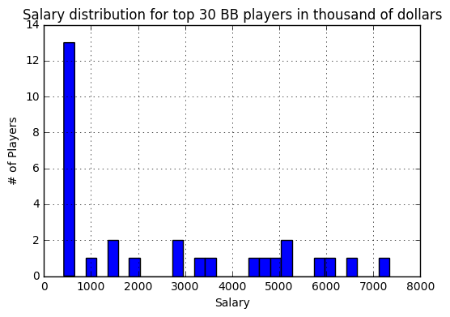

```python
fig, ax = plt.subplots()
plt.hist(bestBBplayers['salary'][:30]/1000, bins=30, normed=False)
plt.xlabel('Salary')
plt.ylabel('# of Players')
plt.title('Salary distribution for top 30 BB players in thousand of dollars')
plt.grid(True)
plt.show()
```